# Loss Aversion - Learning Rates

Kyle Murphy

11/4/2018

### Loss Aversion and the Sunk Cost Fallacy

#### **Focus:**

Examine people’s decisions in an environment where the ‘odds are against against them’. How quickly do people recognize a “bad bet” and under what circumstances?

*Loss Aversion* is the tendency to prefer avoiding losses to acquiring equivalent gains. Individuals commit the *Sunk Cost Fallacy* when they continue a behavior or endeavor as a result of previously invested resources (time, money or effort) (Arkes & Blumer, 1985).

#### **Research Goal:**

Examine the effects of the Sunk Cost fallacy on betting procedure.

##### **Questions:**

Does the Sunk Cost Fallacy have an effect on “betting” size?

How quickly are “bad odds” recognized?

#### **Research Procedure:**

We will present participants with a betting scenario of our design. We may pose this betting scenario as a “weighted die roll” or “stock purchase” or “sports bet” with simple terms.

The participant is **not** explicitly told about the properties of the distribution beforehand.

```r
n = 10000
sd = .1
mean = -.1
```

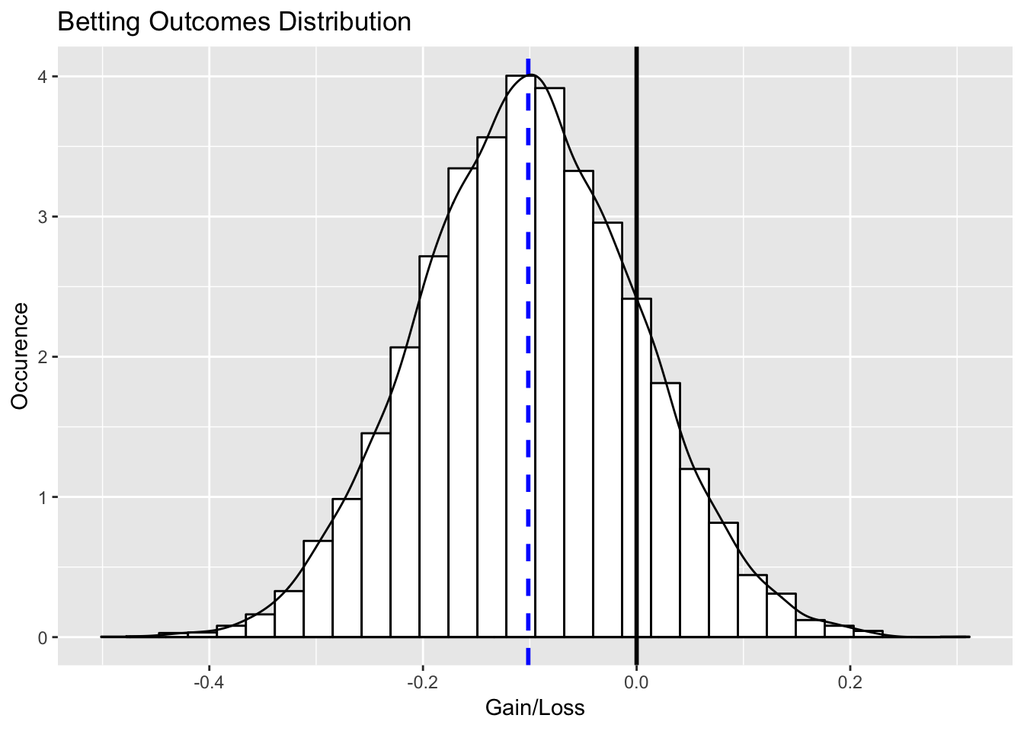

###### Summary Distribution Statistics

```
##     Outcome
##  Min.   :-0.47773
##  1st Qu.:-0.17047
##  Median :-0.10191
##  Mean   :-0.10142
##  3rd Qu.:-0.03281
##  Max.   : 0.30799
```

Chances of earnings greater than $0.00 dollars is:

```
## [1] 15.87
```

Each participant is given an endowment and allowed to choose the amount of their endowment they are willing to risk per bet. Here we demonstrate a hypothetical trial with a maximum betting size of 100% given a 100 dollar endowment.

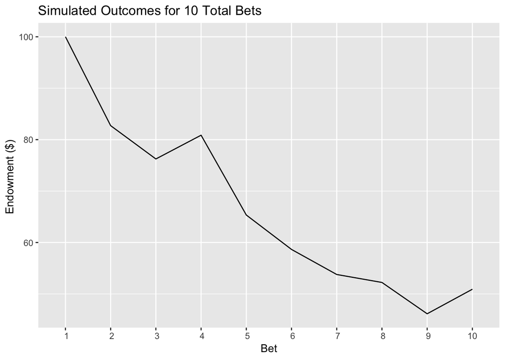

Here we demonstrate the same process for 1000 hypothetical trials

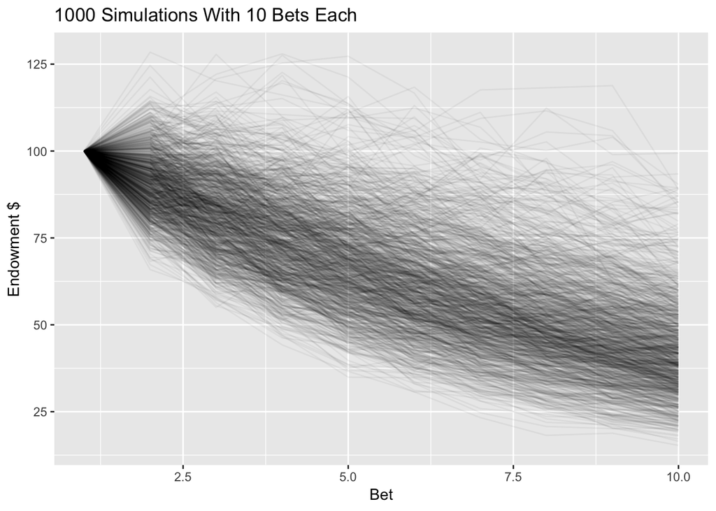

Summary intervals for the end of our simulation:

```
##  0.5%  2.5%   25%   50%   75% 97.5% 99.5%
## 19.09 21.78 33.22 41.14 50.59 76.85 88.95
```

#### **Expected Results:**

###### Analysis:

We are looking to record the *change* in each participant’s betting sizes with every iterative gain or loss, with the purpose of analyzing any relationships between size of gain/loss and subsequent betting size.

- Expected Result: Individuals will *increase* their betting size in some proportion to the amount lost in an attempt to “make the money back”.
- Expected Result: Individuals will play until they go broke.

#### **Challenges:**

- Participants may not mind betting the entire $100 allotment until they go broke - it is not their money (Separate Mental Accounts).

#### **Possible Modifiers:**

- Ask volunteer participants to play with their own money.
- Show participants the probability distribution at some point before/during betting.